# Cancer Rates in the Borders

```r
library(tidyverse)
library(here)
library(janitor)
library(ggplot2)
library(scales)
```

```r
incidence_at_scotland_level <-
  read_csv(here("raw_data/incidence_at_scotland_level.csv"))
incidence_by_healthboard <-
  read_csv(here("raw_data/incidence_by_health_board.csv"))
five_year_incidence_scotland_level <-
  read_csv(here("raw_data/five_year_summary_of_incidence_at_scotland_level.csv"))
five_year_incidence_healthboard <-
  read_csv(here("raw_data/five_year_summary_of_incidence_by_health_board.csv"))
healthboards <- read_csv(here("raw_data/geography_codes_and_labels_hb2014_01042019.csv"))
```

I don’t think I am going to look at Cancer network region (it has 3 regions rather than health boards) or the all of Scotland as can add health boards

```r
incidence_at_scotland_level <-
  janitor::clean_names(incidence_at_scotland_level)

incidence_by_healthboard <-
  janitor::clean_names(incidence_by_healthboard)

five_year_incidence_scotland_level <-
  janitor::clean_names(five_year_incidence_scotland_level)

five_year_incidence_healthboard <-
  janitor::clean_names(five_year_incidence_healthboard)

healthboards <- janitor::clean_names(healthboards)
```

Note - for health board, the focus is the borders.

Join health board names to the health board data

```r
incidence_by_healthboard %>%
  distinct(hb)
```

| hb |
| --- |
| S08000015 |
| S08000016 |
| S08000017 |
| S08000029 |
| S08000019 |
| S08000020 |
| S08000031 |
| S08000022 |
| S08000032 |
| S08000024 |

[output cut: 4 more lines]

```r
incidence_by_hb_name_join <-
  left_join(incidence_by_healthboard, healthboards, "hb")
incidence_by_hb_name_join %>%
  distinct(hb_name)
```

| hb_name |
| --- |
| NHS Ayrshire and Arran |
| NHS Borders |
| NHS Dumfries and Galloway |
| NHS Fife |
| NHS Forth Valley |
| NHS Grampian |
| NHS Greater Glasgow and Clyde |
| NHS Highland |
| NHS Lanarkshire |
| NHS Lothian |

[output cut: 4 more lines]

```r
#14 healthboards

five_year_by_hb_name_join <-
  left_join(five_year_incidence_healthboard, healthboards, "hb")
five_year_by_hb_name_join %>%
  distinct(hb_name)
```

| hb_name |
| --- |
| NHS Ayrshire and Arran |
| NHS Borders |
| NHS Dumfries and Galloway |
| NHS Fife |
| NHS Forth Valley |
| NHS Grampian |
| NHS Greater Glasgow and Clyde |
| NHS Highland |
| NHS Lanarkshire |
| NHS Lothian |

[output cut: 2 more lines]

```r
#12 healthboards
```

```r
# I looked at lots of columns on all df's for NAs
incidence_at_scotland_level %>%
  summarise(sum(is.na(year)))
```

| sum(is.na(year)) |
| --- |
| 0 |

```r
phs_colours <- c("#185ADB", "#3F3685", "#9A62A4", "#9295C0",
                 "#2F86C6", "#F05454", "#72B046", "#3C5511",
                 "#0C7F73", "#9C0F48", "#470D21", "#FC92E3",
                 "#F8CB2E", "#4FD3C4")
# #004785 public health Scotland blue
# #3F3685 public health scot purple
# #9A62A4 another purple
# #9295C0 light purple
# #2F86C6 light blue
# #E5F4FB almost white blue
# #72B046 light bright green
# #3C5511 forest green
# #0C7F73 teal
```

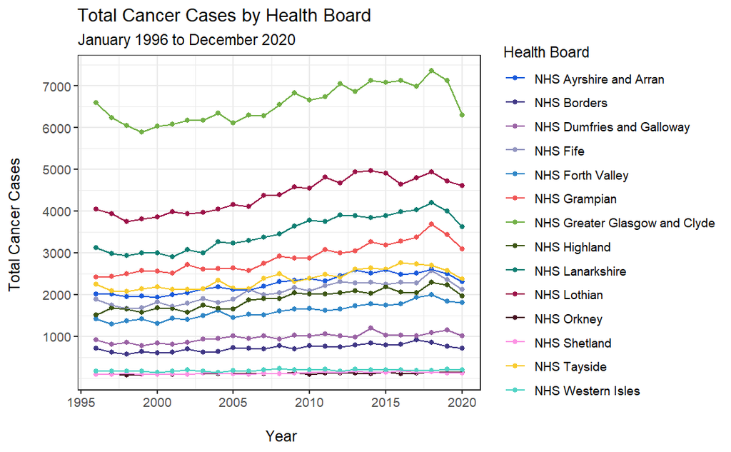

```r
hb_totals_comparison <- incidence_by_hb_name_join %>%
  filter(cancer_site == "All cancer types" & sex == "All")

hb_totals_comparison %>%
  ggplot()+
  aes(x = year,
      y = incidences_all_ages,
      colour = hb_name)+
  geom_point()+
  geom_line()+
  scale_colour_manual(values = c("#185ADB", "#3F3685", "#9A62A4", "#9295C0",
                 "#2F86C6", "#F05454", "#72B046", "#3C5511",
                 "#0C7F73", "#9C0F48", "#470D21", "#FC92E3",
                 "#F8CB2E", "#4FD3C4"))+
  scale_y_continuous(breaks = c(1000, 2000, 3000, 4000, 5000, 6000, 7000, 8000))+
  labs(x = "\n Year",
       y = "Total Cancer Cases \n",
       title = "Total Cancer Cases by Health Board",
       subtitle = "January 1996 to December 2020",
       colour = "Health Board")+
  theme_bw()
```

```r
# incidence_by_hb_name_join %>%
#   group_by(sex) %>%
#   summarise(count = n())
#
# five_year_by_hb_name_join %>%
#   group_by(sex) %>%
#   summarise(count = n())
```

Borders most common cancers by sex…

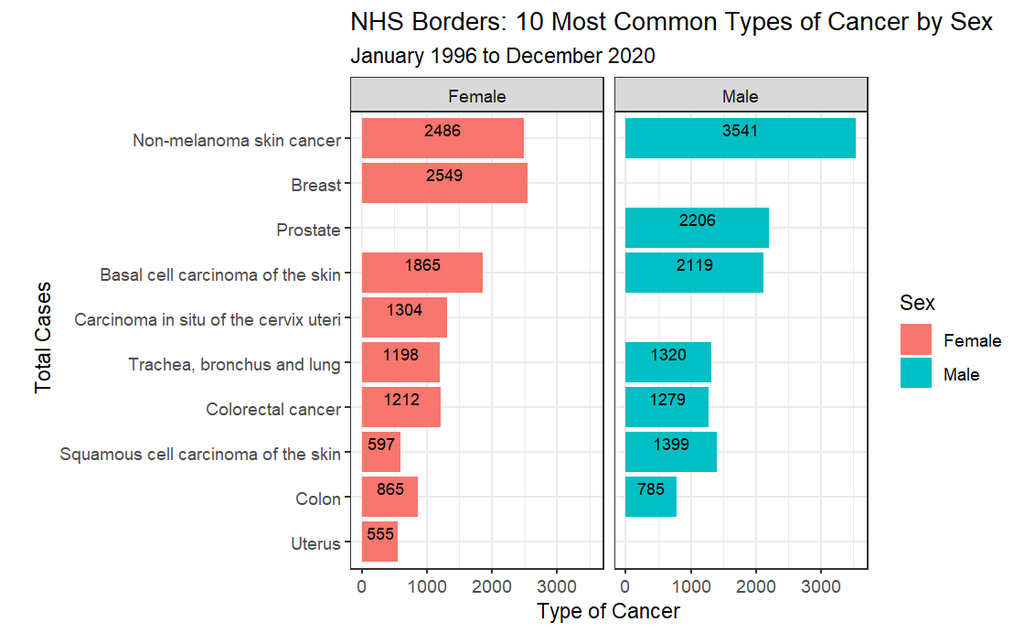

```r
borders_common_cancers_1996_sex <- incidence_by_hb_name_join %>%
  select(cancer_site, year, sex, hb_name, incidences_all_ages) %>%
  filter(cancer_site != "All cancer types"
         & hb_name == "NHS Borders"
         & sex != "All") %>%
  group_by(cancer_site, sex) %>%
  summarise(total_cases_of_cancer = sum(incidences_all_ages)) %>%
  arrange(desc(total_cases_of_cancer))
borders_common_cancers_1996_sex %>%
  filter(total_cases_of_cancer > 500) %>%
  ggplot()+
  aes(x = reorder(cancer_site, total_cases_of_cancer),
      y = total_cases_of_cancer,
      fill = sex)+
  geom_col()+
  coord_flip()+
  facet_wrap(~sex)+
    labs(x = "\n Total Cases",
       y = "Type of Cancer",
       title = "NHS Borders: 10 Most Common Types of Cancer by Sex",
       subtitle = "January 1996 to December 2020",
       fill = "Sex") +
  geom_text(aes(label = total_cases_of_cancer),
            size = 3, vjust = -0.25, position = position_stack(vjust = 0.5))+
  theme_bw()
```

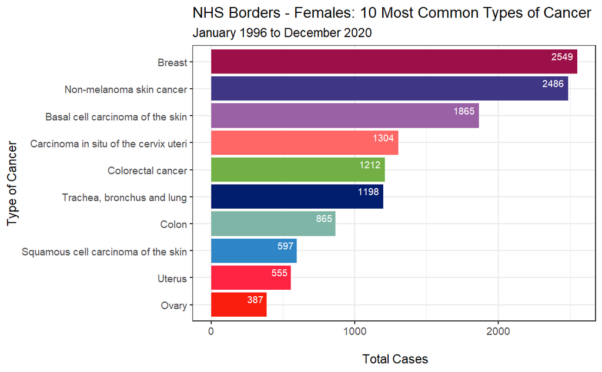

```r
borders_common_cancers_1996_sex %>%
  filter(sex == "Female" & total_cases_of_cancer > 380) %>%
  ggplot()+
  aes(x = reorder(cancer_site, total_cases_of_cancer),
      y = total_cases_of_cancer,
      fill = sex)+
  geom_col(fill = c("#9C0F48", "#3F3685", "#9A62A4", "#FF6767",
                    "#72B046", "#001D6E", "#7EB5A6", "#2F86C6",
                    "#FF2442", "#FA1E0E"))+
  coord_flip()+
  labs(y = "\n Total Cases",
       x = "Type of Cancer",
       title = "NHS Borders - Females: 10 Most Common Types of Cancer",
       subtitle = "January 1996 to December 2020") +
  geom_text(aes(label = total_cases_of_cancer),
            size = 3, vjust = -0.25, hjust = 1.2, colour = "white")+
 # geom_text(aes(label = total_cases_of_cancer),
  #          size = 3, vjust = -0.25, position = position_stack(vjust = 0.5))+
  theme_bw()
```

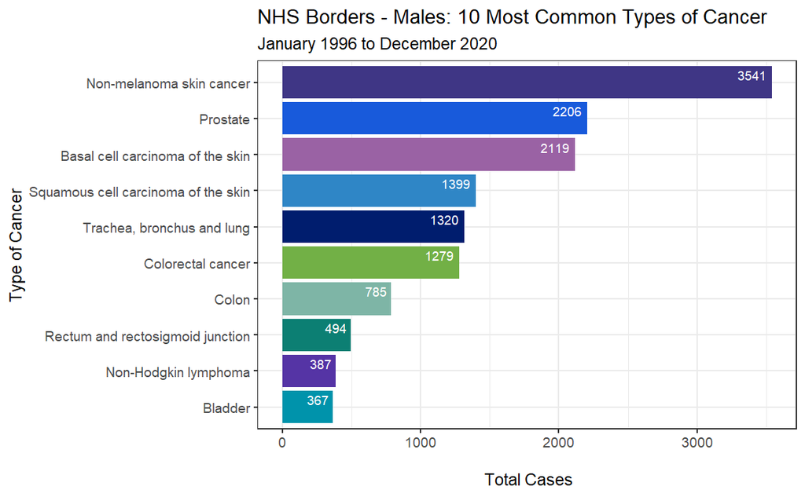

```r
borders_common_cancers_1996_sex %>%
  filter(sex == "Male" & total_cases_of_cancer > 360) %>%
  ggplot()+
  aes(x = reorder(cancer_site, total_cases_of_cancer),
      y = total_cases_of_cancer)+
  geom_col(fill = c("#3F3685", "#185ADB", "#9A62A4",
                 "#2F86C6", "#001D6E", "#72B046",
                 "#7EB5A6", "#0C7F73", "#5534A5", "#0093AB"))+
  coord_flip()+
  labs(y = "\n Total Cases",
       x = "Type of Cancer",
       title = "NHS Borders - Males: 10 Most Common Types of Cancer",
       subtitle = "January 1996 to December 2020") +
  geom_text(aes(label = total_cases_of_cancer),
            size = 3, vjust = -0.25, hjust = 1.2, colour = "white")+
  theme_bw()
```

Borders only - highest rates of cancer

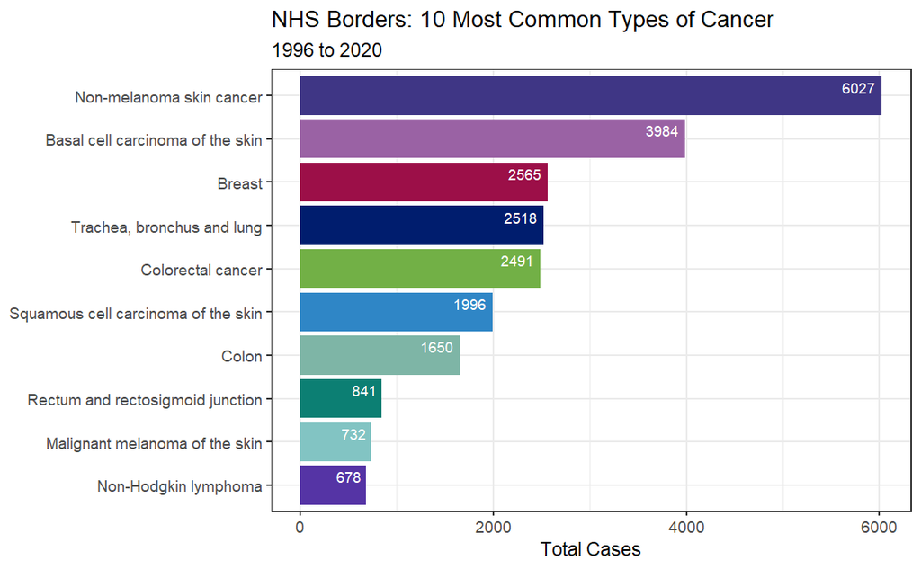

```r
borders_common_cancers_1996 <- incidence_by_hb_name_join %>%
  select(cancer_site, year, sex, hb_name, incidences_all_ages) %>%
  filter(cancer_site != "All cancer types"
         & hb_name == "NHS Borders"
         & sex == "All") %>%
  group_by(cancer_site) %>%
  summarise(total_incidences = sum(incidences_all_ages)) %>%
  arrange(desc(total_incidences))

borders_common_cancers_1996 %>%
  filter(total_incidences > 600) %>%
  ggplot()+
  aes(x = reorder(cancer_site, total_incidences),
      y = total_incidences)+
  geom_col()+
  coord_flip() +
  geom_col(fill = c("#3F3685", "#9A62A4", "#9C0F48", "#001D6E",
                    "#72B046", "#2F86C6", "#7EB5A6", "#0C7F73",
                    "#82C4C3", "#5534A5"))+
  labs(title = "NHS Borders: 10 Most Common Types of Cancer",
       subtitle = "1996 to 2020",
       y = "Total Cases",
       x = NULL)+
  geom_text(aes(label = total_incidences),
            size = 3, vjust = -0.25, hjust = 1.2, colour = "white")+
  theme_bw()
```

Borders only - last 5 years highest rates of cancer

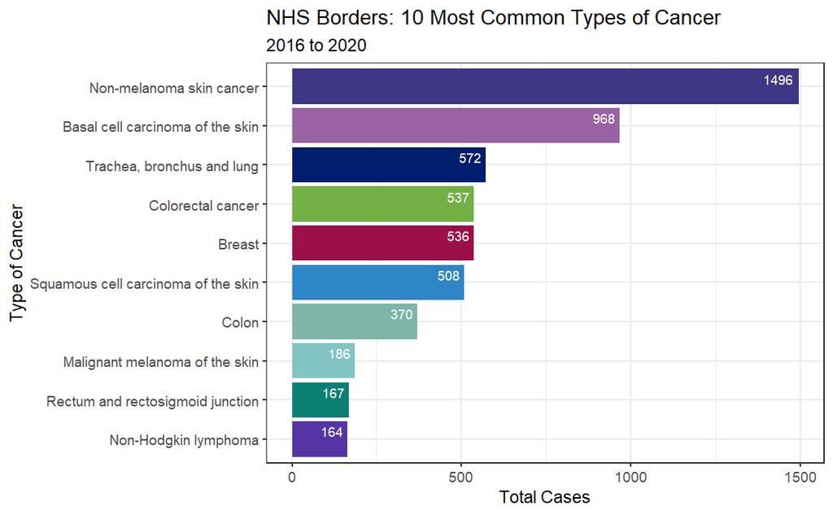

```r
borders_common_cancers_2016 <- five_year_by_hb_name_join %>%
  select(cancer_site, year, sex, hb_name, incidences_all_ages) %>%
  filter(cancer_site != "All cancer types"
         & hb_name == "NHS Borders"
         & sex == "All") %>%
  group_by(cancer_site) %>%
  summarise(total_incidences = sum(incidences_all_ages)) %>%
  arrange(desc(total_incidences))

borders_common_cancers_2016 %>%
  filter(total_incidences > 160) %>%
  ggplot()+
  aes(x = reorder(cancer_site, total_incidences),
      y = total_incidences)+
  geom_col()+
  coord_flip() +
  geom_col(fill = c("#3F3685", "#9A62A4", "#001D6E", "#72B046",
                    "#9C0F48", "#2F86C6", "#7EB5A6", "#82C4C3",
                    "#0C7F73", "#5534A5"))+
  labs(title = "NHS Borders: 10 Most Common Types of Cancer",
       subtitle = "2016 to 2020",
       y = "Total Cases",
       x = "Type of Cancer") +
  geom_text(aes(label = total_incidences),
            size = 3, vjust = -0.25, hjust = 1.2, colour = "white")+
  theme_bw()
```

borders - 5 - sex

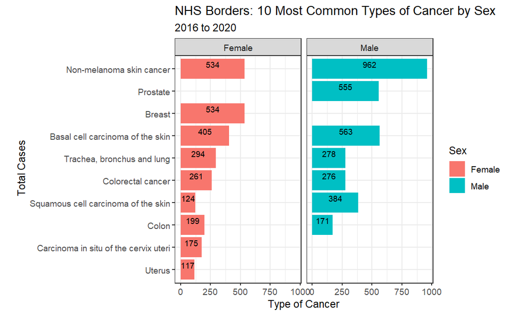

```r
borders_common_cancers_five_sex <- five_year_by_hb_name_join %>%
  select(cancer_site, year, sex, hb_name, incidences_all_ages) %>%
  filter(cancer_site != "All cancer types"
         & hb_name == "NHS Borders"
         & sex != "All") %>%
  group_by(cancer_site, sex) %>%
  summarise(total_cases_of_cancer = sum(incidences_all_ages)) %>%
  arrange(desc(total_cases_of_cancer))
borders_common_cancers_five_sex %>%
  filter(total_cases_of_cancer > 110) %>%
  ggplot()+
  aes(x = reorder(cancer_site, total_cases_of_cancer),
      y = total_cases_of_cancer,
      fill = sex)+
  geom_col()+
  coord_flip()+
  facet_wrap(~sex)+
    labs(x = "\n Total Cases",
       y = "Type of Cancer",
       title = "NHS Borders: 10 Most Common Types of Cancer by Sex",
       subtitle = "2016 to 2020",
       fill = "Sex") +
  geom_text(aes(label = total_cases_of_cancer),
            size = 3, vjust = -0.25, position = position_stack(vjust = 0.5))+
  theme_bw()
```

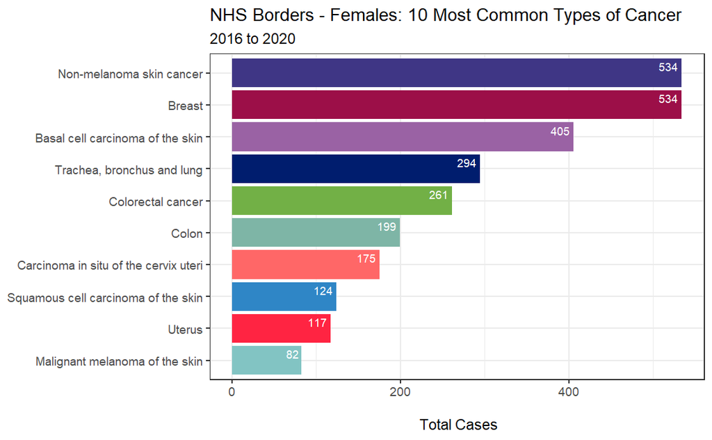

```r
borders_common_cancers_five_sex %>%
  filter(sex == "Female" & total_cases_of_cancer > 81) %>%
  ggplot()+
  aes(x = reorder(cancer_site, total_cases_of_cancer),
      y = total_cases_of_cancer)+
  geom_col()+
  coord_flip()+
  geom_col(fill = c("#9C0F48", "#3F3685", "#9A62A4",
                    "#001D6E","#72B046", "#7EB5A6", "#FF6767",
                     "#2F86C6", "#FF2442",
                    "#82C4C3"))+
  labs(y = "\n Total Cases",
       x = NULL,
       title = "NHS Borders - Females: 10 Most Common Types of Cancer",
       subtitle = "2016 to 2020") +
  geom_text(aes(label = total_cases_of_cancer),
            size = 3, vjust = -0.25, hjust = 1.2, colour = "white")+
 # geom_text(aes(label = total_cases_of_cancer),
  #          size = 3, vjust = -0.25, position = position_stack(vjust = 0.5))+
  theme_bw()
```

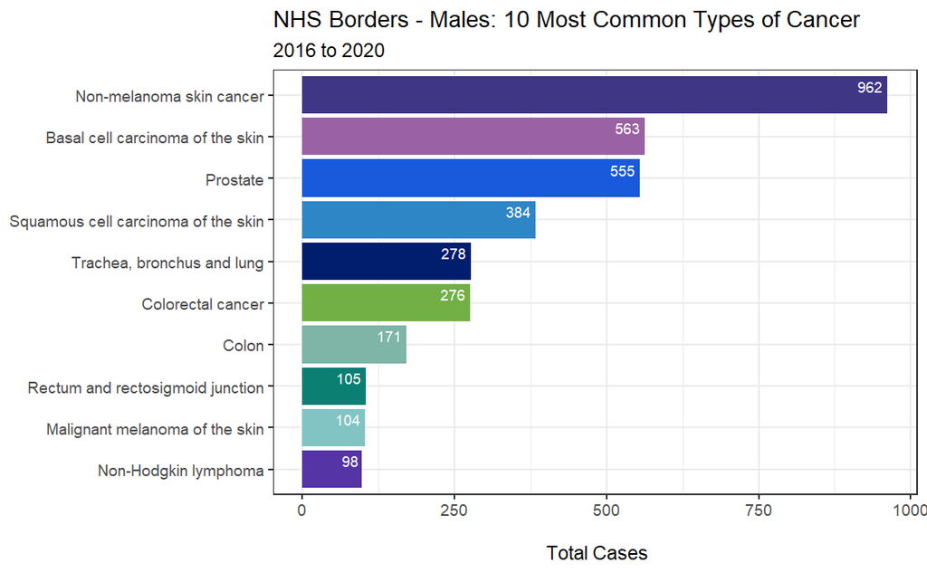

```r
borders_common_cancers_five_sex %>%
  filter(sex == "Male" & total_cases_of_cancer > 90) %>%
  ggplot()+
  aes(x = reorder(cancer_site, total_cases_of_cancer),
      y = total_cases_of_cancer)+
  geom_col()+
  coord_flip()+
  geom_col(fill = c("#3F3685", "#9A62A4", "#185ADB",
                    "#2F86C6", "#001D6E", "#72B046",
                    "#7EB5A6", "#0C7F73",
                    "#82C4C3", "#5534A5"))+
  labs(y = "\n Total Cases",
       x = NULL,
       title = "NHS Borders - Males: 10 Most Common Types of Cancer",
       subtitle = "2016 to 2020") +
  geom_text(aes(label = total_cases_of_cancer),
            size = 3, vjust = -0.25, hjust = 1.2, colour = "white")+
  theme_bw()
```

Borders only - male vs female

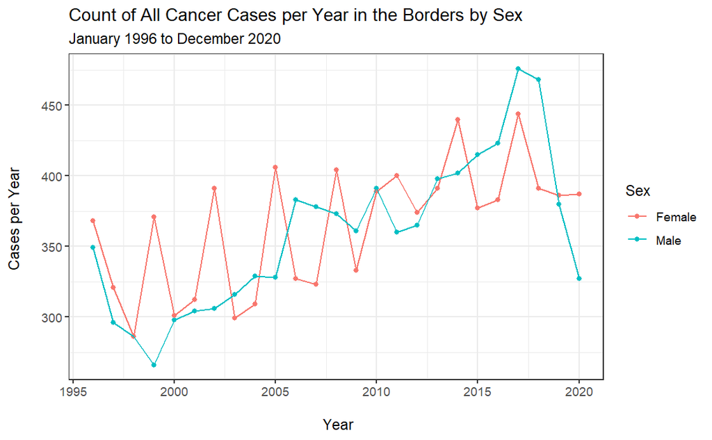

```r
borders_incidences_sex <- incidence_by_hb_name_join %>%
  filter(sex != "All" &
           hb_name == "NHS Borders" &
           cancer_site == "All cancer types")

borders_incidences_sex %>%
  ggplot()+
  aes(x = year,
      y = incidences_all_ages,
      group = sex,
      colour = sex)+
  geom_point() +
  geom_line()+
  labs(x = "\n Year",
       y = "Cases per Year \n",
       colour = "Sex",
       title = "Count of All Cancer Cases per Year in the Borders by Sex",
       subtitle = "January 1996 to December 2020")+
  theme_bw()
```

in comparison with all of scotland…

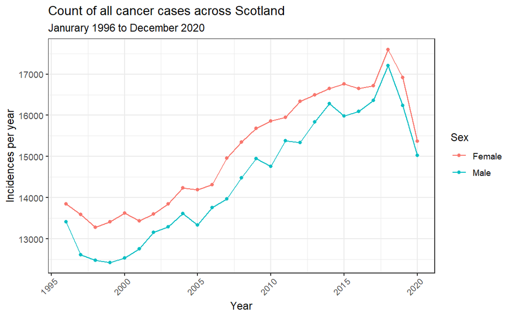

```r
scotland_incidences_sex <- incidence_at_scotland_level %>%
  filter(sex != "All"
         & cancer_site == "All cancer types") %>%
  group_by(year, sex) %>%
  mutate(total_incidences_per_year = sum(incidences_all_ages), .after = 2)

scotland_incidences_sex %>%
  ggplot()+
  aes(x = year,
      y = total_incidences_per_year,
      group = sex,
      colour = sex)+
  geom_point() +
  geom_line()+
  labs(x = "Year",
       y = "Incidences per year",
       colour = "Sex",
       title = "Count of all cancer cases across Scotland",
       subtitle = "Janurary 1996 to December 2020")+
  theme_bw()+
  theme(axis.text.x = element_text(angle=45, hjust=0.9))
```

Looked up crude rate but I’m not 100% sure how I would use it: A crude rate is defined as the total number of events, or count, divided by the mid-year total population of the selected geography and multiplied by a constant, which is a multiple of 10. Typical constants used for public health rates include 100, 1,000, 10,000, or 100,000.

BUT considering the standardised incidence ratio: an SIR is the ratio of the observed number of cancer cases to the expected number of cases multiplied by 100. An SIR of 100 indicates that the number of cancer cases observed in the population evaluated is equal to the number of cancer cases expected in the comparison or “normal” population. This is why in “incidence_at_scotland_level” all the SIR are 100.

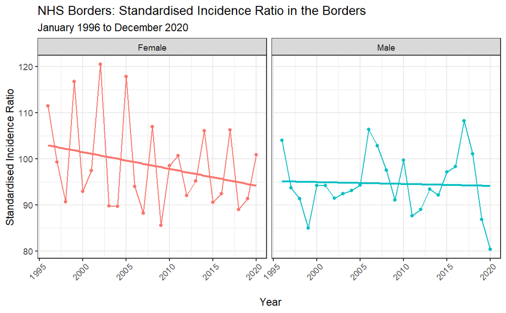

```r
borders_incidences_sex %>%
    ggplot()+
  aes(x = year,
      y = standardised_incidence_ratio,
      group = sex,
      colour = sex)+
  geom_point() +
  geom_line() +
  facet_wrap(~sex)+
  geom_smooth(method='lm', se = FALSE)+
  labs(x = "\n Year",
       y = "Standardised Incidence Ratio",
       title = "NHS Borders: Standardised Incidence Ratio in the Borders",
       subtitle = "January 1996 to December 2020")+
  guides(colour = "none") +
  theme_bw()+
  theme(axis.text.x = element_text(angle=45, hjust=0.9))
```